# Anexo 1. Ejemplo simplificado de ontología y grafo de conocimiento para MO-4

Representación didáctica de un activo turístico mediante R

Equipo UIB - IAIB / MoDAE / GREI

2026-05-21

# 1 Objetivo del anexo

Este anexo muestra, de forma simplificada, cómo puede representarse un activo turístico del módulo MO-4 como un pequeño grafo de conocimiento.

El objetivo no es sustituir la arquitectura real de la Plataforma Inteligente de Destinos (PID), ni reproducir de forma completa la Ontología del Turismo de SEGITTUR. El objetivo es mostrar de manera comprensible cómo una ontología define clases y relaciones, y cómo un grafo permite representar activos concretos siguiendo esa estructura.

La idea central es la siguiente:

> La ontología define el significado.  
> El grafo conecta los datos reales siguiendo ese significado.

En este ejemplo se usa el activo turístico **Playa de Muro**. Podría sustituirse por cualquier otro activo del catálogo MO-4: un museo, una oficina de turismo, una ruta, un evento, un alojamiento o un servicio público.

# 2 Preparación del entorno

```r
# Paquetes necesarios para construir y visualizar el grafo.
# Si no están instalados, descomenta las líneas siguientes:

# install.packages("igraph")
# install.packages("tibble")
# install.packages("dplyr")

library(igraph)
library(tibble)
library(dplyr)
```

# 3 Idea conceptual

Una ontología turística funciona como un **lenguaje común** para describir el destino. Define clases, propiedades y relaciones.

Por ejemplo:

- una **playa** puede ser un tipo de **recurso de interés turístico**;
- un **hotel** puede ser un tipo de **alojamiento**;
- una **oficina de turismo** puede ser un tipo de **servicio público**;
- un **evento** puede celebrarse en un municipio o en un recurso concreto;
- un activo turístico puede tener localización, horario, descripción, multimedia, accesibilidad, idioma disponible y canales de publicación.

El grafo de conocimiento representa casos concretos siguiendo esa lógica. Así, **Playa de Muro** deja de ser solo una fila en una tabla y pasa a ser un nodo conectado con municipio, servicios, canales digitales, indicadores y otros activos.

# 4 Definición de nodos

En un grafo, los **nodos** representan entidades.

En este ejemplo mezclamos tres tipos de nodos:

1. **Clases ontológicas**, como `Recurso turístico` o `Playa`.
2. **Instancias concretas**, como `Playa de Muro`.
3. **Entidades relacionadas**, como municipio, servicios, canales digitales o indicadores.

```r
# Tabla de nodos del grafo.
# Cada fila representa una entidad.
#
# El prefijo "seg:" se usa aquí para representar clases inspiradas
# en la Ontología del Turismo de SEGITTUR.
#
# El prefijo "mo4:" se usa para representar entidades concretas
# del catálogo MO-4 de Mallorca.
#
# Esto es solo una convención didáctica para el ejemplo.

nodes <- tribble(
  ~id,                         ~label,                         ~tipo,
  "seg:RecursoTuristico",      "Recurso de interés turístico", "Clase ontológica",
  "seg:Playa",                 "Playa",                        "Clase ontológica",
  "seg:Evento",                "Evento",                       "Clase ontológica",
  "mo4:PlayaDeMuro",           "Playa de Muro",                "Activo MO-4",
  "mo4:MunicipioMuro",         "Municipio de Muro",            "Territorio",
  "mo4:Socorrismo",            "Servicio de socorrismo",       "Servicio público",
  "mo4:Aparcamiento",          "Aparcamiento cercano",         "Servicio",
  "mo4:Accesibilidad",         "Accesibilidad parcial",        "Atributo",
  "mo4:Imagenes",              "Imágenes y multimedia",        "Contenido",
  "mo4:AppTurista",            "App Turista",                  "Canal digital",
  "mo4:PortalDestino",         "Portal Destino",               "Canal digital",
  "mo4:IndicadorSaturacion",   "Indicador de saturación",      "Indicador"
)

nodes
```

```
## # A tibble: 12 × 3
##    id                      label                        tipo
##    <chr>                   <chr>                        <chr>
##  1 seg:RecursoTuristico    Recurso de interés turístico Clase ontológica
##  2 seg:Playa               Playa                        Clase ontológica
##  3 seg:Evento              Evento                       Clase ontológica
##  4 mo4:PlayaDeMuro         Playa de Muro                Activo MO-4
##  5 mo4:MunicipioMuro       Municipio de Muro            Territorio
##  6 mo4:Socorrismo          Servicio de socorrismo       Servicio público
##  7 mo4:Aparcamiento        Aparcamiento cercano         Servicio
##  8 mo4:Accesibilidad       Accesibilidad parcial        Atributo
##  9 mo4:Imagenes            Imágenes y multimedia        Contenido
## 10 mo4:AppTurista          App Turista                  Canal digital
## 11 mo4:PortalDestino       Portal Destino               Canal digital
## 12 mo4:IndicadorSaturacion Indicador de saturación      Indicador
```

# 5 Definición de relaciones

En un grafo, las **aristas** representan relaciones entre nodos.

En términos semánticos, cada relación puede entenderse como un triple:

> sujeto — predicado — objeto

Por ejemplo:

> Playa de Muro — está en — Municipio de Muro

```r
# Tabla de relaciones del grafo.
# Cada fila representa una conexión entre dos entidades.
#
# En RDF esto se expresaría como triples.
# Aquí lo representamos mediante una tabla sencilla
# para facilitar su comprensión y análisis en R.

edges <- tribble(
  ~from,                 ~to,                         ~relacion,
  "seg:Playa",           "seg:RecursoTuristico",      "subclase_de",
  "mo4:PlayaDeMuro",     "seg:Playa",                 "es_un_tipo_de",
  "mo4:PlayaDeMuro",     "mo4:MunicipioMuro",         "esta_en",
  "mo4:PlayaDeMuro",     "mo4:Socorrismo",            "dispone_de",
  "mo4:PlayaDeMuro",     "mo4:Aparcamiento",          "tiene_cerca",
  "mo4:PlayaDeMuro",     "mo4:Accesibilidad",         "tiene_atributo",
  "mo4:PlayaDeMuro",     "mo4:Imagenes",              "tiene_contenido",
  "mo4:PlayaDeMuro",     "mo4:AppTurista",            "se_publica_en",
  "mo4:PlayaDeMuro",     "mo4:PortalDestino",         "se_publica_en",
  "mo4:PlayaDeMuro",     "mo4:IndicadorSaturacion",   "tiene_indicador"
)

edges
```

```
## # A tibble: 10 × 3
##    from            to                      relacion
##    <chr>           <chr>                   <chr>
##  1 seg:Playa       seg:RecursoTuristico    subclase_de
##  2 mo4:PlayaDeMuro seg:Playa               es_un_tipo_de
##  3 mo4:PlayaDeMuro mo4:MunicipioMuro       esta_en
##  4 mo4:PlayaDeMuro mo4:Socorrismo          dispone_de
##  5 mo4:PlayaDeMuro mo4:Aparcamiento        tiene_cerca
##  6 mo4:PlayaDeMuro mo4:Accesibilidad       tiene_atributo
##  7 mo4:PlayaDeMuro mo4:Imagenes            tiene_contenido
##  8 mo4:PlayaDeMuro mo4:AppTurista          se_publica_en
##  9 mo4:PlayaDeMuro mo4:PortalDestino       se_publica_en
## 10 mo4:PlayaDeMuro mo4:IndicadorSaturacion tiene_indicador
```

# 6 Construcción del grafo

Con las tablas de nodos y relaciones se puede construir un grafo dirigido.

Un grafo dirigido permite representar relaciones con sentido:

> Playa de Muro → está en → Municipio de Muro

```r
# Construcción del grafo a partir de las tablas anteriores.

g <- graph_from_data_frame(
  d = edges,
  vertices = nodes,
  directed = TRUE
)

g
```

```
## IGRAPH 43fdff0 DN-- 12 10 --
## + attr: name (v/c), label (v/c), tipo (v/c), relacion (e/c)
## + edges from 43fdff0 (vertex names):
##  [1] seg:Playa      ->seg:RecursoTuristico
##  [2] mo4:PlayaDeMuro->seg:Playa
##  [3] mo4:PlayaDeMuro->mo4:MunicipioMuro
##  [4] mo4:PlayaDeMuro->mo4:Socorrismo
##  [5] mo4:PlayaDeMuro->mo4:Aparcamiento
##  [6] mo4:PlayaDeMuro->mo4:Accesibilidad
##  [7] mo4:PlayaDeMuro->mo4:Imagenes
##  [8] mo4:PlayaDeMuro->mo4:AppTurista
## + ... omitted several edges
```

# 7 Visualización del grafo

La siguiente figura muestra la representación simplificada del activo **Playa de Muro** como grafo.

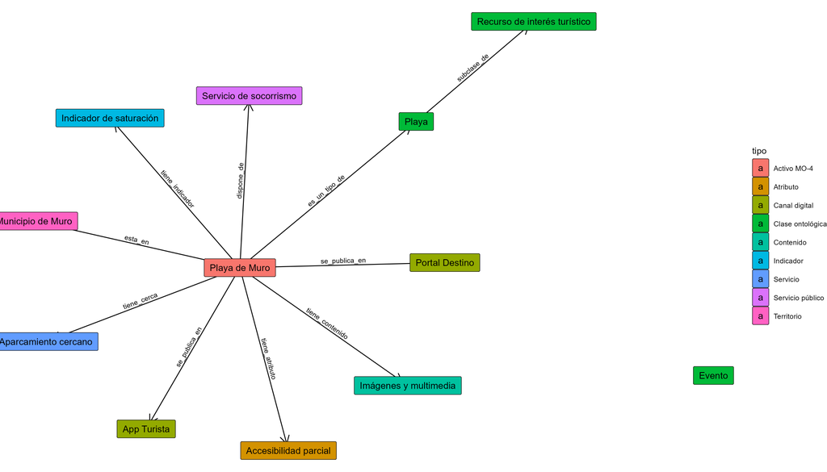

```r
knitr::include_graphics("grafo1_muro.png")
```

El gráfico anterior es una versión mejorada del código

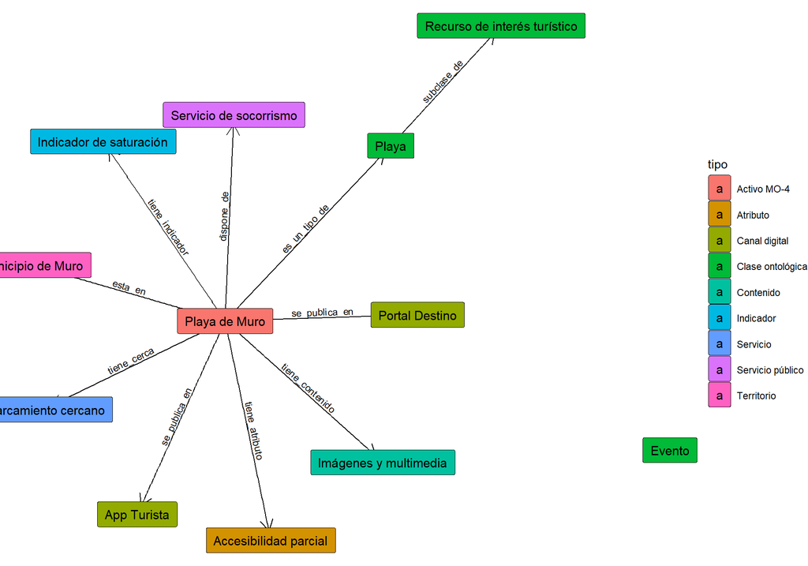

```r
# dibujo con ggprah

library(ggraph)
library(grid)

set.seed(123)

ggraph(g, layout = "fr") +
  geom_edge_link(
    aes(label = relacion),
    arrow = arrow(length = unit(4, "mm")),
    end_cap = circle(3, "mm"),
    label_size = 3,
    label_dodge = unit(2, "mm"),
    angle_calc = "along"
  ) +
  geom_node_label(
    aes(label = label, fill = tipo),
    size = 4,
    label.padding = unit(0.5, "lines"),
    label.r = unit(0.1, "lines")
  ) +
  theme_void()
```

```r
  #+ggtitle("Ejemplo simplificado de grafo MO-4: Playa de Muro")
# gruardar gráfico
ggsave(
  filename = "grafo1_muro.png",
  width = 14,
  height = 8,
  dpi = 300
)
```

# 8 Lectura del ejemplo

Este grafo permite interpretar el activo turístico de forma más rica que una tabla convencional.

En una tabla, **Playa de Muro** sería una fila con campos.

En el grafo, **Playa de Muro** es una entidad conectada con otras entidades:

- una clase ontológica;
- un municipio;
- servicios;
- atributos;
- contenidos;
- canales digitales;
- indicadores.

```r
# Relaciones directas del activo Playa de Muro.

relaciones_playa <- edges %>%
  filter(from == "mo4:PlayaDeMuro") %>%
  left_join(nodes, by = c("to" = "id")) %>%
  select(
    activo = from,
    relacion,
    entidad_relacionada = label,
    tipo_entidad = tipo
  )

relaciones_playa
```

```
## # A tibble: 9 × 4
##   activo          relacion        entidad_relacionada     tipo_entidad
##   <chr>           <chr>           <chr>                   <chr>
## 1 mo4:PlayaDeMuro es_un_tipo_de   Playa                   Clase ontológica
## 2 mo4:PlayaDeMuro esta_en         Municipio de Muro       Territorio
## 3 mo4:PlayaDeMuro dispone_de      Servicio de socorrismo  Servicio público
## 4 mo4:PlayaDeMuro tiene_cerca     Aparcamiento cercano    Servicio
## 5 mo4:PlayaDeMuro tiene_atributo  Accesibilidad parcial   Atributo
## 6 mo4:PlayaDeMuro tiene_contenido Imágenes y multimedia   Contenido
## 7 mo4:PlayaDeMuro se_publica_en   App Turista             Canal digital
## 8 mo4:PlayaDeMuro se_publica_en   Portal Destino          Canal digital
## 9 mo4:PlayaDeMuro tiene_indicador Indicador de saturación Indicador
```

# 9 Ejemplo de consulta analítica

Una ventaja del grafo es que permite hacer consultas sobre relaciones.

Por ejemplo, podemos preguntar:

> ¿Con qué entidades está conectada Playa de Muro?

```r
# Vecinos directos de Playa de Muro.
# mode = "out" indica que buscamos relaciones que salen desde Playa de Muro.

vecinos <- neighbors(
  graph = g,
  v = "mo4:PlayaDeMuro",
  mode = "out"
)

V(g)[vecinos]$label
```

```
## [1] "Playa"                   "Municipio de Muro"
## [3] "Servicio de socorrismo"  "Aparcamiento cercano"
## [5] "Accesibilidad parcial"   "Imágenes y multimedia"
## [7] "App Turista"             "Portal Destino"
## [9] "Indicador de saturación"
```

También podemos calcular qué nodos tienen más conexiones.

```r
# Grado de salida: número de relaciones que salen de cada nodo.
# En este ejemplo, Playa de Muro tendrá muchas relaciones porque es el activo central.

grado_salida <- tibble(
  id = V(g)$name,
  label = V(g)$label,
  tipo = V(g)$tipo,
  grado_salida = degree(g, mode = "out")
) %>%
  arrange(desc(grado_salida))

grado_salida
```

```
## # A tibble: 12 × 4
##    id                      label                        tipo        grado_salida
##    <chr>                   <chr>                        <chr>              <dbl>
##  1 mo4:PlayaDeMuro         Playa de Muro                Activo MO-4            9
##  2 seg:Playa               Playa                        Clase onto…            1
##  3 seg:RecursoTuristico    Recurso de interés turístico Clase onto…            0
##  4 seg:Evento              Evento                       Clase onto…            0
##  5 mo4:MunicipioMuro       Municipio de Muro            Territorio             0
##  6 mo4:Socorrismo          Servicio de socorrismo       Servicio p…            0
##  7 mo4:Aparcamiento        Aparcamiento cercano         Servicio               0
##  8 mo4:Accesibilidad       Accesibilidad parcial        Atributo               0
##  9 mo4:Imagenes            Imágenes y multimedia        Contenido              0
## 10 mo4:AppTurista          App Turista                  Canal digi…            0
## 11 mo4:PortalDestino       Portal Destino               Canal digi…            0
## 12 mo4:IndicadorSaturacion Indicador de saturación      Indicador              0
```

En un grafo real del MO-4, este tipo de análisis permitiría detectar:

- activos muy conectados;
- activos poco documentados;
- municipios con baja cobertura;
- recursos sin localización;
- activos sin contenidos multimedia;
- servicios turísticos no vinculados a canales digitales;
- zonas con muchos recursos pero pocos servicios asociados.

# 10 Validación mínima de calidad del dato

Una ontología no solo sirve para clasificar. También ayuda a definir qué datos mínimos debería tener cada activo.

Por ejemplo, una ficha mínima de activo turístico podría exigir:

- clase o tipo de activo;
- municipio;
- localización;
- descripción;
- canal de publicación;
- estado de actualización.

Aquí se muestra una validación muy sencilla.

```r
# Definimos las relaciones mínimas esperadas para un activo turístico.
# Esto es un ejemplo simplificado.
# En una implementación real podrían usarse reglas SHACL sobre RDF.

relaciones_minimas <- c(
  "es_un_tipo_de",
  "esta_en",
  "se_publica_en"
)

# Extraemos las relaciones disponibles para Playa de Muro.

relaciones_disponibles <- edges %>%
  filter(from == "mo4:PlayaDeMuro") %>%
  pull(relacion)

# Comprobamos qué relaciones mínimas faltan.

relaciones_faltantes <- setdiff(
  relaciones_minimas,
  relaciones_disponibles
)

if (length(relaciones_faltantes) == 0) {
  print("El activo cumple las relaciones mínimas del ejemplo.")
} else {
  print("Faltan relaciones mínimas:")
  print(relaciones_faltantes)
}
```

```
## [1] "El activo cumple las relaciones mínimas del ejemplo."
```

# 11 Ejemplo de ampliación con otro activo

Ahora añadimos un segundo activo, por ejemplo un evento.

Esto permite mostrar cómo el grafo crece conectando activos entre sí y cómo puede apoyar análisis entre módulos.

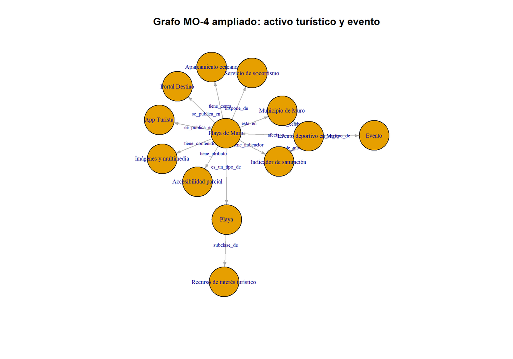

```r
# Nuevo nodo: evento turístico o cultural.

nuevo_nodo <- tribble(
  ~id,                         ~label,                         ~tipo,
  "mo4:EventoDeportivoMuro",   "Evento deportivo en Muro",     "Evento MO-4"
)

# Nuevas relaciones.

nuevas_relaciones <- tribble(
  ~from,                        ~to,                         ~relacion,
  "mo4:EventoDeportivoMuro",    "seg:Evento",                "es_un_tipo_de",
  "mo4:EventoDeportivoMuro",    "mo4:MunicipioMuro",         "se_celebra_en",
  "mo4:EventoDeportivoMuro",    "mo4:PlayaDeMuro",           "afecta_a",
  "mo4:EventoDeportivoMuro",    "mo4:IndicadorSaturacion",   "puede_modificar"
)

# Combinamos nodos y relaciones.

nodes_2 <- bind_rows(nodes, nuevo_nodo)
edges_2 <- bind_rows(edges, nuevas_relaciones)

# Reconstruimos el grafo ampliado.

g2 <- graph_from_data_frame(
  d = edges_2,
  vertices = nodes_2,
  directed = TRUE
)

plot(
  g2,
  vertex.label = V(g2)$label,
  vertex.size = 28,
  vertex.label.cex = 0.7,
  edge.arrow.size = 0.4,
  edge.label = E(g2)$relacion,
  edge.label.cex = 0.6,
  main = "Grafo MO-4 ampliado: activo turístico y evento"
)
```

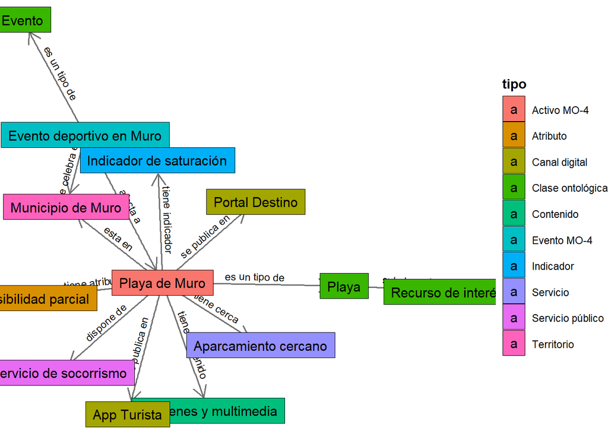

```r
# ============================================================
# Grafo MO-4 ampliado: activo turístico y evento
# ============================================================

library(tidyverse)
library(igraph)
library(ggraph)
library(grid)

# ------------------------------------------------------------
# 1. Nuevo nodo: evento turístico o cultural
# ------------------------------------------------------------

nuevo_nodo <- tribble(
  ~id,                       ~label,                     ~tipo,
  "mo4:EventoDeportivoMuro", "Evento deportivo en Muro", "Evento MO-4"
)

# ------------------------------------------------------------
# 2. Nuevas relaciones del evento
# ------------------------------------------------------------

nuevas_relaciones <- tribble(
  ~from,                     ~to,                       ~relacion,
  "mo4:EventoDeportivoMuro", "seg:Evento",              "es_un_tipo_de",
  "mo4:EventoDeportivoMuro", "mo4:MunicipioMuro",       "se_celebra_en",
  "mo4:EventoDeportivoMuro", "mo4:PlayaDeMuro",         "afecta_a",
  "mo4:EventoDeportivoMuro", "mo4:IndicadorSaturacion", "puede_modificar"
)

# ------------------------------------------------------------
# 3. Unimos los nodos y relaciones existentes con los nuevos
# ------------------------------------------------------------

nodes_2 <- bind_rows(nodes, nuevo_nodo)

edges_2 <- bind_rows(edges, nuevas_relaciones)

# ------------------------------------------------------------
# 4. Construimos el grafo ampliado
# ------------------------------------------------------------

g2 <- graph_from_data_frame(
  d = edges_2,
  vertices = nodes_2,
  directed = TRUE
)

# ------------------------------------------------------------
# 5. Dibujamos el grafo con ggraph
# ------------------------------------------------------------

set.seed(123)

p_grafo_mo4_evento <- ggraph(g2, layout = "fr") +

  geom_edge_link(
    aes(label = gsub("_", " ", relacion)),
    arrow = arrow(length = unit(4, "mm")),
    end_cap = circle(4, "mm"),
    colour = "grey45",
    width = 0.7,
    label_size = 3,
    label_colour = "black",
    label_dodge = unit(2.5, "mm"),
    angle_calc = "along",
    check_overlap = TRUE
  ) +

  geom_node_label(
    aes(label = label, fill = tipo),
    size = 4,
    colour = "black",
    label.padding = unit(0.45, "lines"),
    label.r = unit(0, "lines"),
    label.size = 0.35
  ) +

  theme_void()  +
  theme(
    plot.title = element_text(
      hjust = 0.5,
      size = 16,
      face = "bold"
    ),
    legend.position = "right",
    legend.title = element_text(face = "bold")
  )

# Mostrar el grafo

p_grafo_mo4_evento
```

```r
# ------------------------------------------------------------
# 6. Guardar el grafo como PNG
# ------------------------------------------------------------

ggsave(
  filename = "grafo_mo4_ampliado_evento.png",
  plot = p_grafo_mo4_evento,
  width = 14,
  height = 8,
  dpi = 300
)
```

# 12 Consulta sobre el grafo ampliado

Ahora podemos preguntar:

> ¿Qué activos o indicadores se ven afectados por el evento?

```r
relaciones_evento <- edges_2 %>%
  filter(from == "mo4:EventoDeportivoMuro") %>%
  left_join(nodes_2, by = c("to" = "id")) %>%
  select(
    evento = from,
    relacion,
    entidad_relacionada = label,
    tipo_entidad = tipo
  )

relaciones_evento
```

```
## # A tibble: 4 × 4
##   evento                  relacion        entidad_relacionada     tipo_entidad
##   <chr>                   <chr>           <chr>                   <chr>
## 1 mo4:EventoDeportivoMuro es_un_tipo_de   Evento                  Clase ontológ…
## 2 mo4:EventoDeportivoMuro se_celebra_en   Municipio de Muro       Territorio
## 3 mo4:EventoDeportivoMuro afecta_a        Playa de Muro           Activo MO-4
## 4 mo4:EventoDeportivoMuro puede_modificar Indicador de saturación Indicador
```

Este ejemplo conecta directamente con una lectura operativa de la PID Mallorca: los eventos no son solo registros de agenda, sino elementos que pueden afectar a saturación, movilidad, recursos turísticos, servicios públicos y planificación territorial.

# 13 Lectura por actores del proyecto

El mismo grafo puede ser útil para perfiles distintos.

```r
lectura_actores <- tribble(
  ~actor, ~lectura_del_grafo,
  "T2C / equipo técnico",
  "Permite diseñar datos estructurados, identificadores, clases, propiedades, APIs, validaciones e integraciones con CMS o servicios comunes.",
  "Universidad / computación estadística",
  "Permite analizar relaciones, calidad del dato, cobertura territorial, activos poco documentados, indicadores de saturación y modelos predictivos.",
  "Economistas de turismo",
  "Permite interpretar el activo como parte de la oferta turística, conectado con movilidad, gasto, alojamiento, eventos, presión territorial y experiencia del visitante.",
  "Fundació / Consell / técnicos públicos",
  "Permite gobernar mejor el catálogo: saber qué existe, qué falta, quién mantiene cada dato, qué se publica y qué decisiones pueden justificarse.",
  "Sector turístico",
  "Permite reutilizar información fiable para productos, recomendaciones, rutas, paquetes, servicios y atención al visitante."
)

lectura_actores
```

```
## # A tibble: 5 × 2
##   actor                                  lectura_del_grafo
##   <chr>                                  <chr>
## 1 T2C / equipo técnico                   Permite diseñar datos estructurados, i…
## 2 Universidad / computación estadística  Permite analizar relaciones, calidad d…
## 3 Economistas de turismo                 Permite interpretar el activo como par…
## 4 Fundació / Consell / técnicos públicos Permite gobernar mejor el catálogo: sa…
## 5 Sector turístico                       Permite reutilizar información fiable …
```

# 14 Interpretación para el MO-4

El ejemplo anterior muestra que el grafo permite conectar distintos módulos y problemas de gestión.

Una playa puede estar relacionada con:

- un municipio;
- servicios públicos;
- canales de publicación;
- indicadores de saturación;
- eventos próximos;
- información de movilidad;
- contenidos multimedia;
- datos de accesibilidad.

Esto permite pasar de una visión de inventario a una visión de sistema.

Para el MO-4, esta lógica es importante porque el catálogo de activos turísticos puede alimentar otros servicios de la PID:

- Portal Destino;
- App Turista;
- Asistente Virtual;
- cuadros de mando;
- módulos de localización;
- análisis de flujos y saturación;
- evaluación del impacto de eventos.

# 15 Conclusión del ejemplo

Este anexo no pretende reproducir la arquitectura técnica completa de la PID. En una implementación real, la representación semántica podría apoyarse en RDF, OWL, SKOS, SHACL, SPARQL y un triplestore como Virtuoso.

El ejemplo sirve para mostrar la lógica de fondo:

1. La ontología define las clases, propiedades y relaciones.
2. El catálogo MO-4 contiene los activos concretos.
3. El grafo conecta esos activos con territorio, servicios, indicadores y canales.
4. La universidad puede explotar esa estructura para análisis estadístico, calidad del dato y modelos.
5. El equipo técnico puede implementarla mediante APIs, CMS semántico y servicios interoperables.
6. La administración puede utilizarla para gobernar mejor la información turística del destino.

En síntesis:

> La ontología aporta el lenguaje común del destino.  
> El grafo convierte ese lenguaje en una red de datos reales, reutilizable para gestión, análisis y servicios turísticos inteligentes.